# Group Assingment

Reece Wooten, Kyle Katzen and Daxi Cheng

12/2/2017

## Question 1

```r
case_data<-read.csv('Case Shipments.csv')
seas_data<-read.csv('Seasonality Index.csv')
seas_data<- rbind(seas_data,seas_data,seas_data,seas_data,seas_data)
```

```r
y<-ts(case_data["Case.Shipments"],frequency = 12)
y_tr <- window(y, start=c(2,1),end=c(4,12))
y_te <- window(y, start=c(5,1), end=c(5,12))

y_reg <-case_data[13:60,"Case.Shipments"]

case_data['lag.cp1']<-slide(case_data, Var = "Consumer.Packs", slideBy = -1,NewVar = 'lag.cp1')['lag.cp1']
case_data['lag.cp2']<-slide(case_data, Var = "Consumer.Packs", slideBy = -2,NewVar = 'lag.cp2')['lag.cp2']
case_data['lag.da1']<-slide(case_data, Var = "Dealer.Allowance", slideBy = -1,NewVar = 'lag.da1')['lag.da1']
case_data['lag.da2']<-slide(case_data, Var = "Dealer.Allowance", slideBy = -2,NewVar = 'lag.da2')['lag.da2']

X_tr <- as.matrix(case_data[13:48,3:8])
X_te <- as.matrix(case_data[49:60,3:8])
X<- as.matrix(case_data[13:60,3:8])
```

```r
mod1_cv<-cv.glmnet(x = X,y = y_reg,nfolds = 10)
best_lam<-mod1_cv$lambda.min
```

```r
mod1_cv.coef=predict(mod1_cv,type='coefficients',s=best_lam)
predict(mod1_cv,type='coefficients',s=best_lam)
```

```
## 7 x 1 sparse Matrix of class "dgCMatrix"
##                              1
## (Intercept)       2.991967e+05
## Consumer.Packs    5.765505e-01
## Dealer.Allowance  8.675884e-02
## lag.cp1          -1.898240e-01
## lag.cp2           .
## lag.da1           1.234026e-02
## lag.da2          -1.072965e-02
```

```r
x_red<-X[,c('Consumer.Packs','Dealer.Allowance','lag.cp1','lag.da1','lag.da2')]
mod2_lm<-lm(y_reg~x_red)
summary(mod2_lm)
```

```
##
## Call:
## lm(formula = y_reg ~ x_red)
##
## Residuals:
##     Min      1Q  Median      3Q     Max
## -148759  -28423     906   31731  185129
##
## Coefficients:
##                         Estimate Std. Error t value Pr(>|t|)
## (Intercept)            2.976e+05  1.831e+04  16.256  < 2e-16 ***
## x_redConsumer.Packs    5.926e-01  6.979e-02   8.491 1.17e-10 ***
## x_redDealer.Allowance  8.835e-02  1.029e-02   8.585 8.66e-11 ***
## x_redlag.cp1          -1.966e-01  6.818e-02  -2.884  0.00617 **
## x_redlag.da1           1.387e-02  1.037e-02   1.337  0.18857
## x_redlag.da2          -1.261e-02  1.038e-02  -1.215  0.23126
## ---
## Signif. codes:  0 '***' 0.001 '**' 0.01 '*' 0.05 '.' 0.1 ' ' 1
##
## Residual standard error: 61560 on 42 degrees of freedom
## Multiple R-squared:  0.7693, Adjusted R-squared:  0.7419
## F-statistic: 28.01 on 5 and 42 DF,  p-value: 2.284e-12
```

```r
x_red_tr<-X_tr[,c('Consumer.Packs','Dealer.Allowance','lag.cp1')]
x_red_te<-X_te[,c('Consumer.Packs','Dealer.Allowance','lag.cp1')]
```

## Question 2

### Figure 2.0

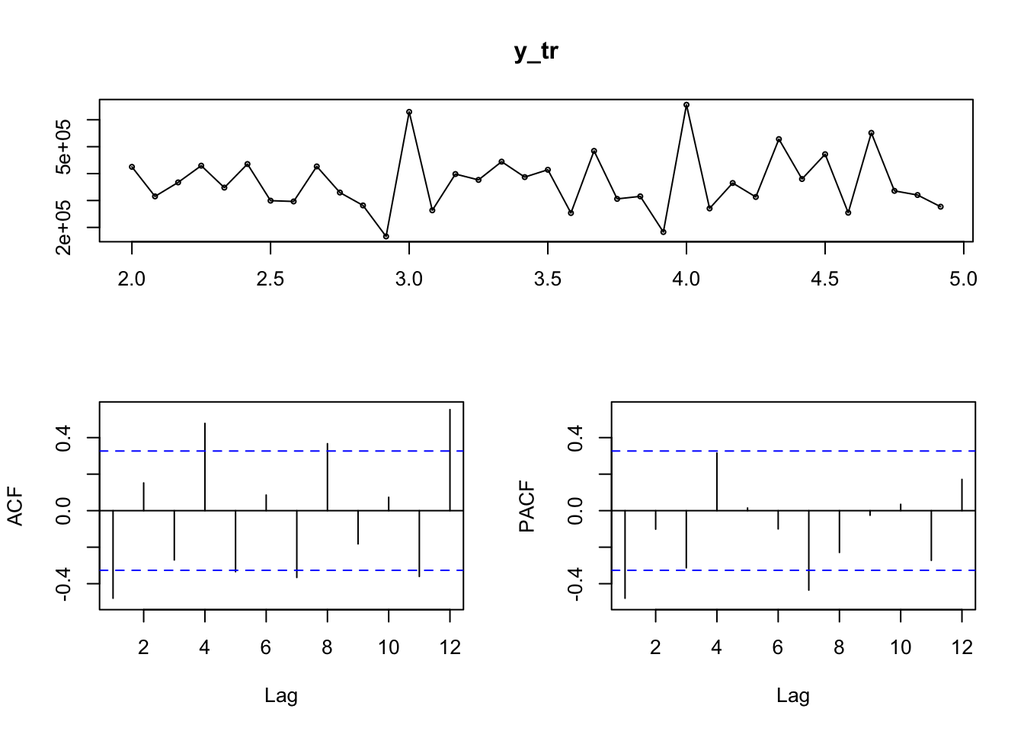

```r
tsdisplay(y_tr)
```

```r
mod3<-Arima(y_tr,order = c(1,2,2),seasonal = c(0,0,2),xreg = x_red_tr)
summary(mod3)
```

```
## Series: y_tr
## Regression with ARIMA(1,2,2)(0,0,2)[12] errors
##
## Coefficients:
##           ar1      ma1     ma2    sma1    sma2  Consumer.Packs
##       -0.6054  -1.2112  0.2112  1.5964  0.9998          0.4967
## s.e.   0.2182   0.3439  0.3400  1.4182  1.4501          0.0850
##       Dealer.Allowance  lag.cp1
##                 0.1428  -0.0322
## s.e.            0.0297   0.0599
##
## sigma^2 estimated as 1.249e+09:  log likelihood=-418.39
## AIC=854.78   AICc=862.28   BIC=868.52
##
## Training set error measures:
##                    ME     RMSE      MAE        MPE     MAPE      MASE
## Training set 2070.435 30038.34 21582.25 -0.8361139 6.096753 0.4143205
##                     ACF1
## Training set -0.03810906
```

### Figure 2.1

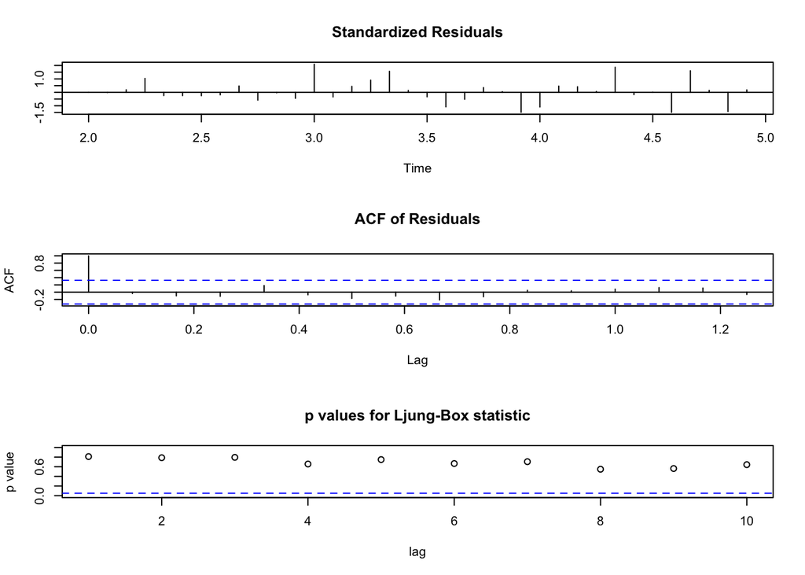

```r
tsdiag(mod3)
```

### Figure 2.2

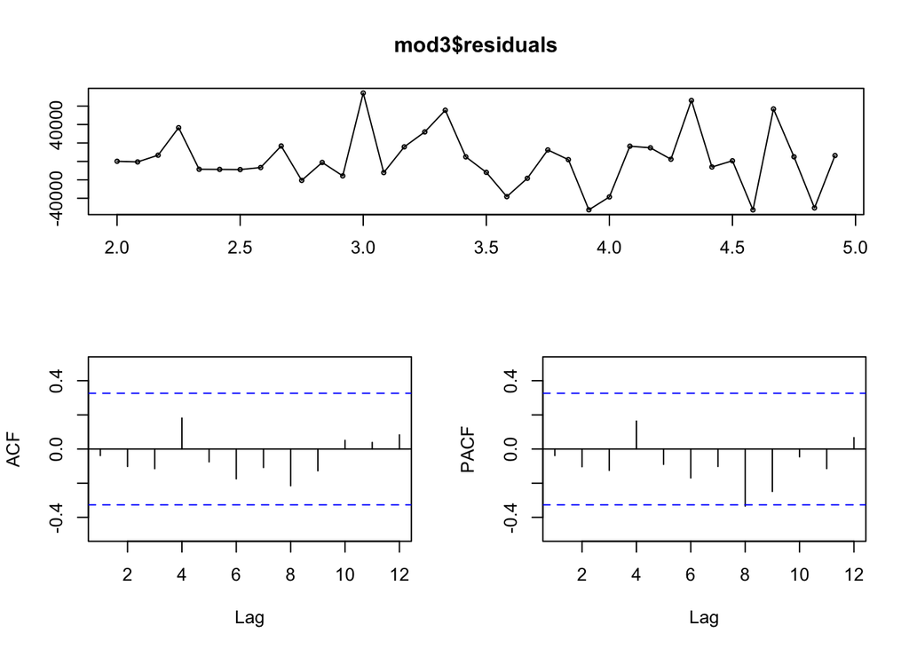

```r
tsdisplay(mod3$residuals)
```

### Figure 2.3

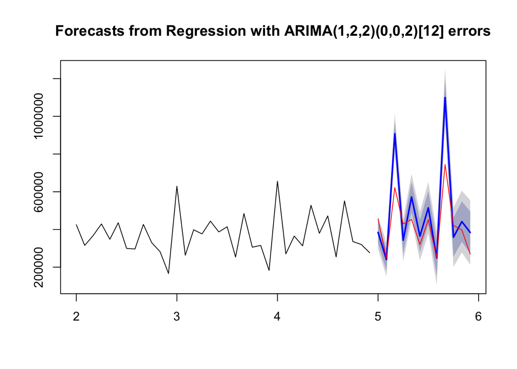

```r
for_non_seas<-forecast(mod3,xreg =x_red_te,h=12 )
plot(for_non_seas)
lines(y_te,col='red')
```

## Question 3

```r
seas_index<-seas_data['Seasonality.Index']/100
y_adj<-ts(case_data['Case.Shipments']/seas_index,frequency = 12)
y_adj1<-case_data['Case.Shipments']/seas_index

y_tr_adj <- window(y_adj, start=c(2,1),end=c(4,12))
y_te_adj <- window(y_adj, start=c(5,1), end=c(5,12))

y_reg_adj <-y_adj1[13:60,"Case.Shipments"]
```

```r
mod2_cv<-cv.glmnet(x = X,y = y_reg_adj,nfolds = 10)
best_lam2<-mod2_cv$lambda.min
```

```r
mod2_cv.coef=predict(mod2_cv,type='coefficients',s=best_lam2)
predict(mod2_cv,type='coefficients',s=best_lam2)
```

```
## 7 x 1 sparse Matrix of class "dgCMatrix"
##                              1
## (Intercept)       3.154805e+05
## Consumer.Packs    4.130257e-01
## Dealer.Allowance  6.970589e-02
## lag.cp1          -1.568864e-01
## lag.cp2           1.346546e-02
## lag.da1           1.078562e-02
## lag.da2          -1.017676e-02
```

```r
x_red<-X[,c('Consumer.Packs','Dealer.Allowance','lag.cp1','lag.cp2','lag.da1','lag.da2')]
mod3_lm<-lm(y_reg_adj~x_red)
summary(mod3_lm)
```

```
##
## Call:
## lm(formula = y_reg_adj ~ x_red)
##
## Residuals:
##    Min     1Q Median     3Q    Max
## -73660 -23447   -183  20783  94090
##
## Coefficients:
##                         Estimate Std. Error t value Pr(>|t|)
## (Intercept)            3.141e+05  1.200e+04  26.178  < 2e-16 ***
## x_redConsumer.Packs    4.228e-01  4.199e-02  10.068 1.20e-12 ***
## x_redDealer.Allowance  7.044e-02  6.385e-03  11.032 7.61e-14 ***
## x_redlag.cp1          -1.605e-01  4.083e-02  -3.932 0.000317 ***
## x_redlag.cp2           1.799e-02  4.219e-02   0.426 0.671976
## x_redlag.da1           1.177e-02  6.270e-03   1.877 0.067696 .
## x_redlag.da2          -1.114e-02  6.308e-03  -1.766 0.084903 .
## ---
## Signif. codes:  0 '***' 0.001 '**' 0.01 '*' 0.05 '.' 0.1 ' ' 1
##
## Residual standard error: 36790 on 41 degrees of freedom
## Multiple R-squared:  0.8496, Adjusted R-squared:  0.8276
## F-statistic: 38.61 on 6 and 41 DF,  p-value: 2.401e-15
```

```r
x_red_tr<-X_tr[,c('Consumer.Packs','Dealer.Allowance','lag.cp1')]
x_red_te<-X_te[,c('Consumer.Packs','Dealer.Allowance','lag.cp1')]
```

### Figure 3.0

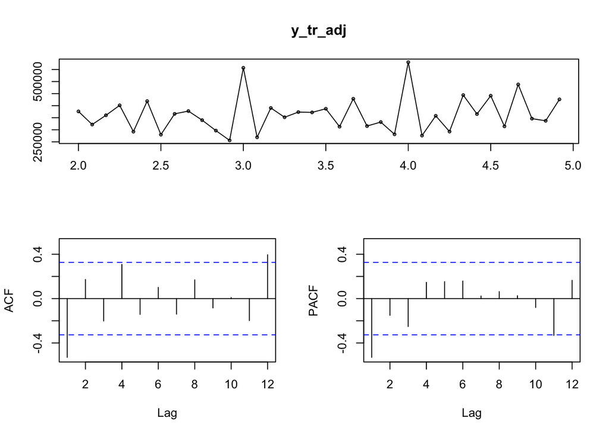

```r
tsdisplay(y_tr_adj)
```

```r
mod3<-Arima(y_tr_adj,order = c(2,2,2),seasonal = c(2,0,1),xreg = x_red_tr)
summary(mod3)
```

```
## Series: y_tr_adj
## Regression with ARIMA(2,2,2)(2,0,1)[12] errors
##
## Coefficients:
##           ar1     ar2      ma1     ma2     sar1     sar2    sma1
##       -0.3108  0.2118  -1.0829  0.0831  -0.4325  -0.9214  0.9552
## s.e.   0.7458  0.4013   0.7304  0.7204   0.1771   0.0620  4.0600
##       Consumer.Packs  Dealer.Allowance  lag.cp1
##               0.4391            0.1008  -0.1561
## s.e.          0.0231            0.0127   0.0200
##
## sigma^2 estimated as 188202179:  log likelihood=-399.44
## AIC=820.87   AICc=832.87   BIC=837.66
##
## Training set error measures:
##                     ME     RMSE      MAE        MPE     MAPE      MASE
## Training set -924.6516 11201.26 8970.035 -0.3582875 2.560787 0.1746097
##                     ACF1
## Training set -0.06095108
```

### Figure 3.1

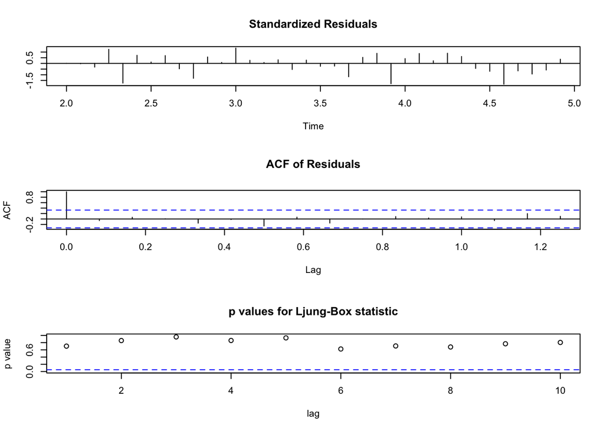

```r
tsdiag(mod3)
```

### Figure 3.2

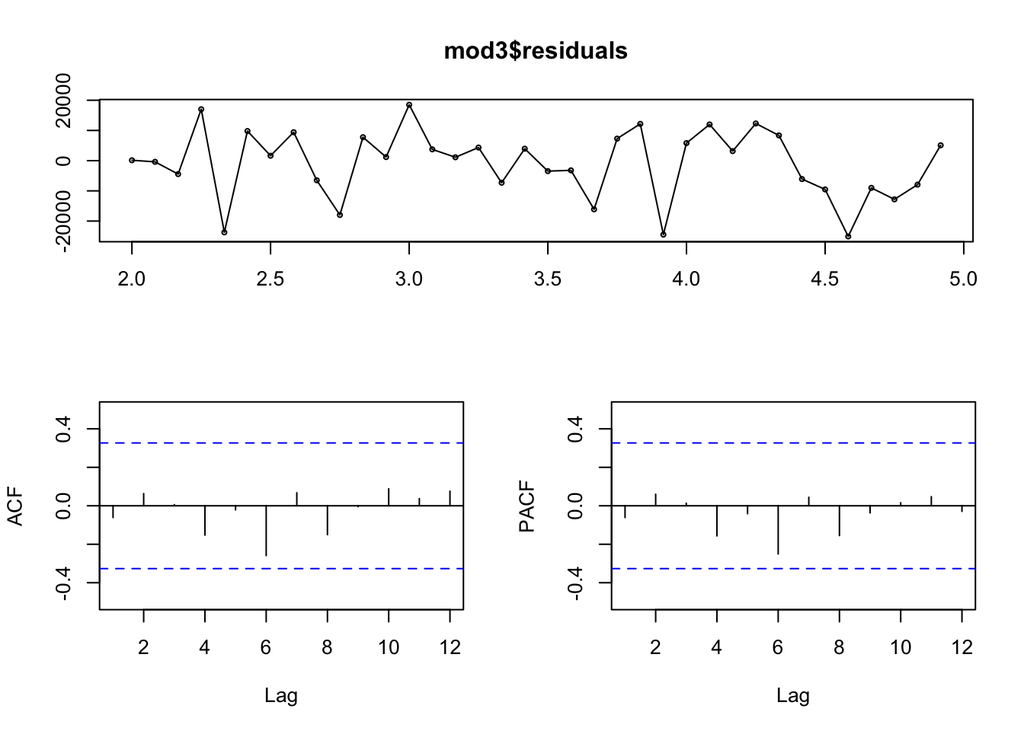

```r
tsdisplay(mod3$residuals)
```

```r
seas_index_12<-seas_data['Seasonality.Index'][49:60,]
```

### Figure 3.2

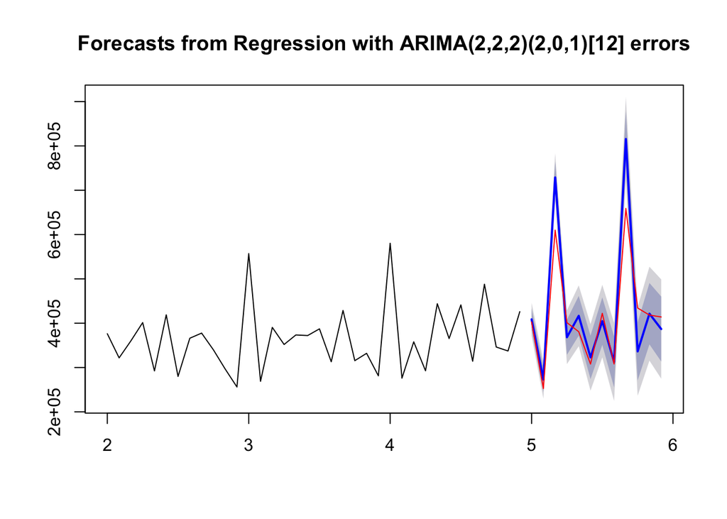

```r
for2<-forecast(mod3,xreg =x_red_te,h=12)
plot(for2)
lines(y_te_adj,col='red')
```

## Question 4

### Analysis

- We can see from the result of the dynamic regression in question 3 that the coeeficient for consumer packs is 0.4391 which means a unit of consumer packs in time t will result in about 0.44 unit of increase of case shipment increase during time t the same period. However, the effect of lag1 consumer packs of -0.1561 means that this will also result a decrease of about 0.16 unit of case shipment next period t+1. This is the forward buying effect that we got from the regression above.

## Question 5

### Analysis

- Starting with a lasso regression, none of the variables coefficients converged to zero. So to address their statistical significance they were then put into a linear regression. This showed that only the consumer packs, dealer allowances, and lagged consumer packs were statistically significant. These variables were then put into an arima model which tried to account for its auto correlated errors. The model produced very good forecasts compared to the previous model which wasnt scaled by the seasonal index. The coefficients on consumer packs was .439 and the lagged consumer packs was -.156, indicating a stock up in the subsequent month. The dealer allowance had a smaller yet positive coef. .1008, which didnt have a lagged effect.
- While consumer packs have a larger effect than dealer allowances, consumer packs also have significant stock ups. Given this information, dealer allowances would allow Harmon foods to more stably increase sales, without the harm of stock ups. If Harmon foods wanted to use consumer packs as an advertising strategy they would need to be conscious of the stock ups and prepare their supply chain for lower demand in the subsequent month. I would recommend Dealer Allowances as a main strategy for Harmon Foods because of its predictable sales increase without the stock up risk.